# Univariate Exploration

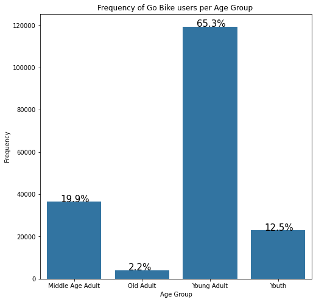

### We can say that users mostly use Go bike are Young Adults

##### Youth 15year : 24 year

##### Youth Adult 25year : 39 year

##### Middle Age Adult 40 year : 59 year

##### Old Adult more than 60 years

# Bivariate Exploration

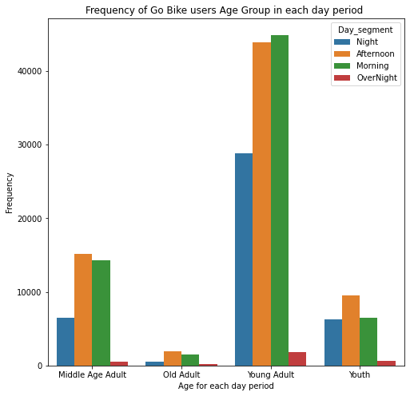

#### Young Adults Adults prefer to take their rides in the morning but the other age groups prefer to take their rides afternoon

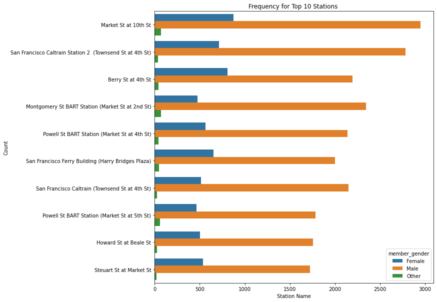

We can see the most favorable start stations for each gender in this graph we can realize that markaer st at 10th is favorable for all genders

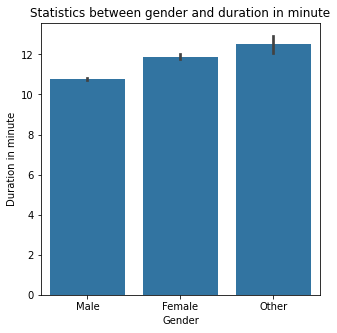

Males tend to go for shorter rides than the females

### Conclusion for previous Plots

firstly we made univariate Exploration to find some info about the dataset like histogram to remove outliers and countplots to know the structure of the data Then we made Bivariate Exploration to find statistical relations between features (categorical and numerical)  
Now, we need to go more far and make multivariate Exploration to see the whole effect of each feature belong to the other features